# Transit Equity and Built Environment Disparities: Omaha Metro vs. Council Bluffs

# 3 3 Results:

## 3.1 Metropolitan Disparities and Differences Between Metros

Are there differences in transit access between Omaha and Iowa metro areas and are they explained by typical urban population gradients or as a result of the boundary between the two states?

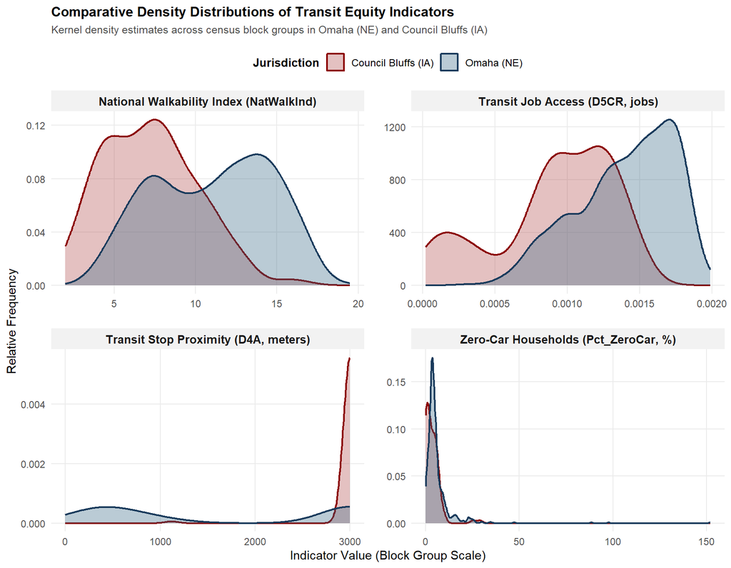

Figure 3.1: Comparative Density Distributions of Built Environment and Transit Equity Indicators Between Council Bluffs (IA) and Omaha (NE).

**Transit Need vs Job Accessibility**

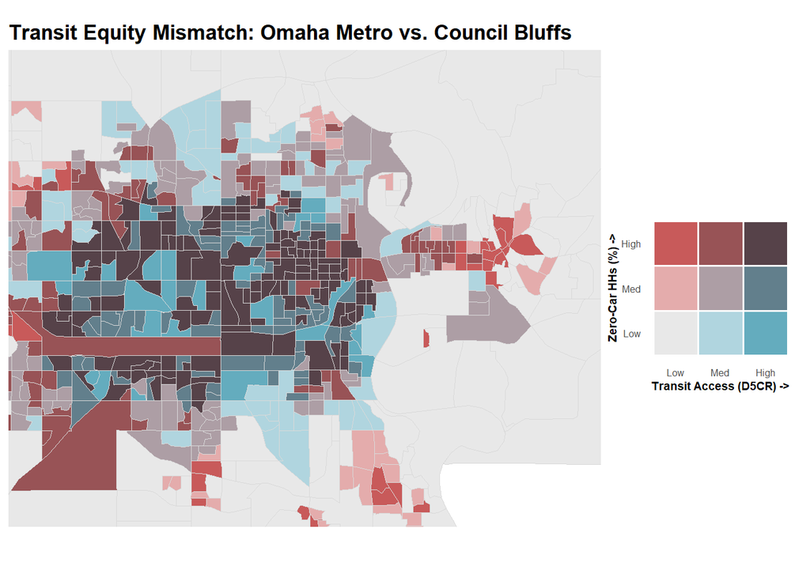

Figure 3.2: Spatial mismatch between zero-vehicle household and job accessibility.

**Physical Transit Stop Proximity Role in Job Access**

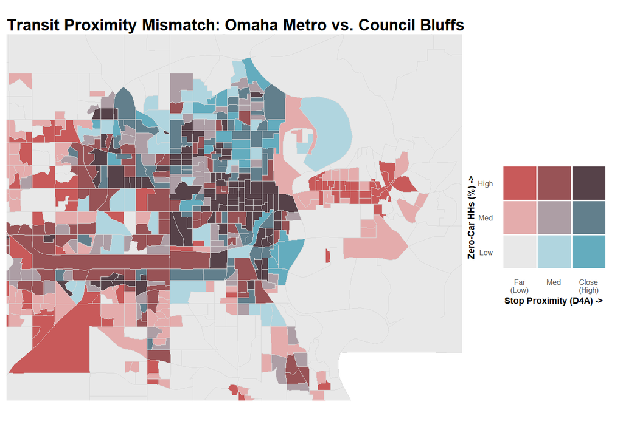

Figure 3.3: Walking proximity and percent of zero car households.

Council Bluff has an access cliff at the state line where bus services are limited and reliance on cars is much greater when compared to Omaha. Council Bluffs resident rely on jobs located within the core metro area of Omaha but are cut off due to poor transit services and lack of a vehicle. An interstate partnership from Council Bluffs to key job areas in Omaha is needed to bridge the job accessibility gap that exists between the two cities. Additionally land use reforms in commercial areas within Council Bluffs to promote greater walkability through more protected pedestrian crossings and continuous sidewalk networks.This would also reduce walking barriers to transit hubs in areas with higher population density. Additionally a shared bus pass system between Omaha and Council Bluffs may help to reduce friction between the two systems as well as make it more realistic for individuals to transfer from different bus routes without long wait times.